# Regression ANalysis on Spotify Song Attributes - MATH564

## **Introduction**

**Problem Statement:** The analysis seeks to understand the relationship between various song attributes and their total playback time (`msPlayed`) on Spotify. The goal is to determine which factors significantly influence the playback duration and to identify patterns or trends in the dataset.

**Project Goal:** To build a regression model that can predict song playback time (`msPlayed`) based on continuous attributes like `danceability`, `energy`, and `tempo`, and categorical attributes like `genre` and `artistName`.

**Expected Results/Outcomes:**

- A well-fitted regression model that explains variations in playback time.
- Insights into how song features (both categorical and continuous) influence user engagement.
- Identification and remediation of issues in the regression model to improve accuracy and reliability.

**Dataset Introduction:** The Spotify Song Attributes dataset contains 22 variables related to music tracks. The key attributes include:

- **Continuous Variables:** `danceability`, `energy`, `tempo`, `loudness`.
- **Categorical Variables:** `genre`, `artistName`.
- **Response Variable:** `msPlayed`, representing the total playback duration in milliseconds.

The dataset consists of 10,080 records, with some columns containing missing values or inconsistencies. Cleaning and preprocessing are essential to ensure the quality of insights and predictions.

## **Project Workflow**

### **Part 1: Initial Analysis**

This phase establishes the groundwork for model development, including data preparation, feature selection, model specification, and statistical analysis.

#### **Dataset Selection and Exploration**

1. Choosing a real-world dataset containing both continuous and categorical variables.
2. Identifying response and predictor variables:
   - **Response Variable**: `msPlayed`.
   - **Predictors**:
     - Continuous: `danceability`, `energy`, `tempo`.
     - Categorical: `genre`, `artistName`.

#### **Data Cleaning**

1. Handling missing values:
   - Identifying and addressing missing values in relevant columns.
   - Removing rows or imputing values as needed.
2. Cleaning categorical variables:
   - Standardizing columns like `genre` and `artistName` (e.g., lowercasing, grouping rare categories under “Other”).
   - Ensuring consistent formatting (removing whitespaces, handling special characters).
3. Outlier handling:
   - Identifying extreme values in continuous features and addressing them appropriately.
4. Normalizing continuous variables:
   - Scaling variables like `danceability`, `energy`, and `tempo` to ensure comparability.

#### **Model Specification**

1. Defining and fitting a multiple linear regression model:
   - Response Variable: `msPlayed`.
   - Predictors: `danceability`, `energy`, `tempo`, `genre`, `artistName`.
2. Evaluating model significance:
   - Analyzing $F$-statistics to assess overall model significance.

#### **Statistical Significance and Interpretation**

1. Analyzing the significance of each regressor:
   - Reporting p-values and confidence intervals for each predictor.
2. Interpreting regression coefficients:
   - Explaining the effect of predictors on `msPlayed`.
   - For categorical variables, discussing the effect of different categories.
3. Assessing goodness-of-fit metrics:
   - Computing $R^2$ and adjusted $R^2$.

### **Part 2: Regression Diagnostics**

This phase focuses on verifying model assumptions and identifying potential issues.

#### **Assumptions and Potential Issues**

1. Investigating model assumptions:
   - Testing for autocorrelation (Durbin-Watson test or similar).
   - Checking for heteroscedasticity using diagnostic plots and statistical tests.
   - Assessing multicollinearity through Variance Inflation Factor (VIF).
   - Identifying influential points using Cook’s Distance and leverage values.
2. Understanding implications:
   - Discussing how issues like heteroscedasticity, multicollinearity, or influential points affect model reliability.

### **Part 3: Remediation and Refinement**

This phase addresses identified issues, refines the model, and evaluates improvements.

#### **Remediation**

1. Applying appropriate techniques:
   - Transformations (e.g., logarithmic, square root) to address heteroscedasticity.
   - Weighted Least Squares for heteroscedasticity.
   - Interaction terms or polynomial terms for non-linear relationships.
   - Removing or adjusting for influential points.
   - Combining variables to address multicollinearity.
2. Re-fitting the model:
   - Refining the regression model based on applied techniques.
   - Comparing the refined model’s performance with the original.

### **Summary and Findings**

1. Summarizing project findings:
   - Discussing the significance and interpretation of predictors.
   - Highlighting diagnostic issues identified and their implications.
   - Evaluating the effectiveness of remediation techniques.
2. Concluding remarks:
   - Assessing the final model’s suitability for prediction or inference.
   - Recommending future analysis or potential improvements.

### **1.1 Load the necessary libraries and dataset:**

```r
# Load necessary libraries
library(dplyr)  # For data manipulation
```

```r
library(ggplot2)  # Optional, for visualization if needed
#install.packages("VIM") # KNN imputation
library(VIM)
# Load the Spotify attribute dataset
data <- read.csv("./data/Spotify_Song_Attributes.csv")
# Create a copy of the spotify attribute dataset
spotify_data <- data
# View the first few rows to understand the structure
head(spotify_data)
```

```
##                                                             trackName
## 1                                                            "Honest"
## 2 "In The Hall Of The Mountain King" from Peer Gynt Suite N°1, Op. 46
## 3                                                  #BrooklynBloodPop!
## 4                                                                 $10
## 5                                          (I Just) Died In Your Arms
## 6                                                       (L)only Child
##                  artistName msPlayed             genre danceability energy key
## 1              Nico Collins   191772                          0.476  0.799   4
## 2 London Symphony Orchestra  1806234 british orchestra        0.475  0.130   7
## 3                      SyKo   145610        glitchcore        0.691  0.814   1
## 4              Good Morning    25058  experimental pop        0.624  0.596   4
## 5              Cutting Crew  5504949        album rock        0.625  0.726  11
## 6               salem ilese  2237969             alt z        0.645  0.611   8
##   loudness mode speechiness acousticness instrumentalness liveness valence
```

[output cut: 41 more lines]

#### **Inference**:

The dataset is successfully loaded into R, and a copy (`spotify_data`) is created to preserve the original data. We can now inspect the first few rows to understand its structure.

### **1.2 View Dataset Structure**

```r
# View the structure of the data
str(spotify_data)
```

```
## 'data.frame':    10080 obs. of  22 variables:
##  $ trackName       : chr  "\"Honest\"" "\"In The Hall Of The Mountain King\" from Peer Gynt Suite N°1, Op. 46" "#BrooklynBloodPop!" "$10" ...
##  $ artistName      : chr  "Nico Collins" "London Symphony Orchestra" "SyKo" "Good Morning" ...
##  $ msPlayed        : int  191772 1806234 145610 25058 5504949 2237969 441335 70589 120005 107407 ...
##  $ genre           : chr  "" "british orchestra" "glitchcore" "experimental pop" ...
##  $ danceability    : num  0.476 0.475 0.691 0.624 0.625 0.645 0.663 NA 0.792 0.759 ...
##  $ energy          : num  0.799 0.13 0.814 0.596 0.726 0.611 0.904 NA 0.511 0.699 ...
##  $ key             : num  4 7 1 4 11 8 7 NA 2 0 ...
##  $ loudness        : num  -4.94 -17.72 -3.79 -9.8 -11.4 ...
##  $ mode            : num  0 1 0 1 0 0 1 NA 1 0 ...
##  $ speechiness     : num  0.212 0.051 0.117 0.0314 0.0444 0.137 0.0857 NA 0.0409 0.0307 ...
##  $ acousticness    : num  0.0162 0.916 0.0164 0.475 0.0158 0.29 0.000708 NA 0.124 0.202 ...
##  $ instrumentalness: num  0.00 9.56e-01 0.00 2.03e-01 1.69e-04 2.05e-05 2.89e-01 NA 9.04e-05 1.31e-04 ...
##  $ liveness        : num  0.257 0.101 0.366 0.119 0.0625 0.237 0.341 NA 0.14 0.443 ...
##  $ valence         : num  0.577 0.122 0.509 0.896 0.507 0.645 0.675 NA 0.111 0.907 ...
##  $ tempo           : num  162 112 132 121 125 ...
##  $ type            : chr  "audio_features" "audio_features" "audio_features" "audio_features" ...
##  $ id              : chr  "7dTxqsaFGHOXwtzHINjfHv" "14Qcrx6Dfjvcj0H8oV8oUW" "7K9Z3yFNNLv5kwTjQYGjnu" "3koAwrM1RO0TGMeQJ3qt9J" ...
##  $ uri             : chr  "spotify:track:7dTxqsaFGHOXwtzHINjfHv" "spotify:track:14Qcrx6Dfjvcj0H8oV8oUW" "spotify:track:7K9Z3yFNNLv5kwTjQYGjnu" "spotify:track:3koAwrM1RO0TGMeQJ3qt9J" ...
##  $ track_href      : chr  "https://api.spotify.com/v1/tracks/7dTxqsaFGHOXwtzHINjfHv" "https://api.spotify.com/v1/tracks/14Qcrx6Dfjvcj0H8oV8oUW" "https://api.spotify.com/v1/tracks/7K9Z3yFNNLv5kwTjQYGjnu" "https://api.spotify.com/v1/tracks/3koAwrM1RO0TGMeQJ3qt9J" ...
##  $ analysis_url    : chr  "https://api.spotify.com/v1/audio-analysis/7dTxqsaFGHOXwtzHINjfHv" "https://api.spotify.com/v1/audio-analysis/14Qcrx6Dfjvcj0H8oV8oUW" "https://api.spotify.com/v1/audio-analysis/7K9Z3yFNNLv5kwTjQYGjnu" "https://api.spotify.com/v1/audio-analysis/3koAwrM1RO0TGMeQJ3qt9J" ...
##  $ duration_ms     : num  191948 150827 145611 89509 280400 ...
##  $ time_signature  : num  4 4 4 4 4 3 4 NA 4 4 ...
```

#### **Inference**:

- The dataset contains **10,080 observations** and **22 variables**, including both continuous and categorical attributes.
- Key continuous variables: `msPlayed`, `danceability`, `energy`, `tempo`, and `loudness`.
- Key categorical variables: `genre` and `artistName`.
- Some columns, such as `track_href`, `uri`, and `id`, are non-informative for analysis and can be removed.
- Missing values are present in critical columns like `danceability`, `energy`, and `tempo` (550 rows each).
- Data types are generally appropriate (e.g., numeric for continuous variables, character for categorical), but some categorical variables require standardization (e.g., `genre` and `artistName`).

### **1.3 Statistical Summary of Each Column:**

```r
# View a summary of each column (e.g., min, max, mean, etc.)
summary(spotify_data)
```

```
##   trackName          artistName           msPlayed            genre
##  Length:10080       Length:10080       Min.   :        0   Length:10080
##  Class :character   Class :character   1st Qu.:   136780   Class :character
##  Mode  :character   Mode  :character   Median :   266288   Mode  :character
##                                        Mean   :  1519657
##                                        3rd Qu.:  1186307
##                                        Max.   :158367130
##
##   danceability        energy            key            loudness
##  Min.   :0.0000   Min.   :0.0011   Min.   : 0.000   Min.   :-42.044
##  1st Qu.:0.5090   1st Qu.:0.4030   1st Qu.: 2.000   1st Qu.:-10.189
##  Median :0.6230   Median :0.5890   Median : 5.000   Median : -7.218
##  Mean   :0.6025   Mean   :0.5635   Mean   : 5.242   Mean   : -8.685
##  3rd Qu.:0.7140   3rd Qu.:0.7510   3rd Qu.: 8.000   3rd Qu.: -5.336
##  Max.   :0.9760   Max.   :0.9990   Max.   :11.000   Max.   :  3.010
##  NA's   :550      NA's   :550      NA's   :550      NA's   :550
##       mode         speechiness      acousticness    instrumentalness
##  Min.   :0.0000   Min.   :0.0000   Min.   :0.0000   Min.   :0.0000
##  1st Qu.:0.0000   1st Qu.:0.0361   1st Qu.:0.0538   1st Qu.:0.0000
##  Median :1.0000   Median :0.0479   Median :0.2450   Median :0.0000
##  Mean   :0.6124   Mean   :0.0785   Mean   :0.3629   Mean   :0.1532
##  3rd Qu.:1.0000   3rd Qu.:0.0819   3rd Qu.:0.6680   3rd Qu.:0.0276
##  Max.   :1.0000   Max.   :0.9660   Max.   :0.9960   Max.   :0.9930
##  NA's   :550      NA's   :550      NA's   :550      NA's   :550
##     liveness         valence           tempo            type
##  Min.   :0.0249   Min.   :0.0000   Min.   :  0.00   Length:10080
##  1st Qu.:0.0962   1st Qu.:0.2370   1st Qu.: 97.57   Class :character
##  Median :0.1190   Median :0.4090   Median :119.82   Mode  :character
##  Mean   :0.1746   Mean   :0.4341   Mean   :119.37
##  3rd Qu.:0.2090   3rd Qu.:0.6140   3rd Qu.:139.78
##  Max.   :0.9640   Max.   :0.9860   Max.   :236.20
##  NA's   :550      NA's   :550      NA's   :550
##       id                uri             track_href        analysis_url
##  Length:10080       Length:10080       Length:10080       Length:10080
##  Class :character   Class :character   Class :character   Class :character
##  Mode  :character   Mode  :character   Mode  :character   Mode  :character
##
##
##
##
##   duration_ms      time_signature
##  Min.   :  10027   Min.   :0.000
##  1st Qu.: 161697   1st Qu.:4.000
##  Median : 194286   Median :4.000
##  Mean   : 202931   Mean   :3.917
##  3rd Qu.: 229526   3rd Qu.:4.000
##  Max.   :4581483   Max.   :5.000
##  NA's   :550       NA's   :550
```

#### **Inference**:

With this understanding of the dataset’s structure and attributes, the next step is to identify and select three continuous variables and two categorical variables that are most relevant for modeling. These selected predictors will form the foundation of our regression analysis, guiding feature engineering and model specification.

### 1.4 Select 3 Continuous and 2 Categorical Variables:

The selection of variables is a critical step in regression analysis, as it determines the predictors that will explain the variability in the response variable `(msPlayed)`.

For continuous variables -

- Attributes with **high variability**.
- Strong **relevance** to playback time.
- Minimal **missing values**.

For categorical variables -

- Predictors with **sufficient representation** in the dataset.
- Potential **influence** on playback time based on domain knowledge.

This approach should ensure that the model captures key **patterns** and **interactions** in the data effectively.

#### 1.4.1 Selection of Variables

Let’s start with the Continuous Variables:

```r
# Response Variable
response_variable <- "msPlayed"

# Continuous Variables: Selecting based on variability and relevance

# Checking summary statistics of numeric variables to identify candidates
numeric_cols <- sapply(spotify_data, is.numeric)
numeric_summary <- summary(spotify_data[, numeric_cols])

# Displaying summary for analysis
print(numeric_summary)
```

```
##     msPlayed          danceability        energy            key
##  Min.   :        0   Min.   :0.0000   Min.   :0.0011   Min.   : 0.000
##  1st Qu.:   136780   1st Qu.:0.5090   1st Qu.:0.4030   1st Qu.: 2.000
##  Median :   266288   Median :0.6230   Median :0.5890   Median : 5.000
##  Mean   :  1519657   Mean   :0.6025   Mean   :0.5635   Mean   : 5.242
##  3rd Qu.:  1186307   3rd Qu.:0.7140   3rd Qu.:0.7510   3rd Qu.: 8.000
##  Max.   :158367130   Max.   :0.9760   Max.   :0.9990   Max.   :11.000
##                      NA's   :550      NA's   :550      NA's   :550
##     loudness            mode         speechiness      acousticness
##  Min.   :-42.044   Min.   :0.0000   Min.   :0.0000   Min.   :0.0000
##  1st Qu.:-10.189   1st Qu.:0.0000   1st Qu.:0.0361   1st Qu.:0.0538
##  Median : -7.218   Median :1.0000   Median :0.0479   Median :0.2450
##  Mean   : -8.685   Mean   :0.6124   Mean   :0.0785   Mean   :0.3629
##  3rd Qu.: -5.336   3rd Qu.:1.0000   3rd Qu.:0.0819   3rd Qu.:0.6680
##  Max.   :  3.010   Max.   :1.0000   Max.   :0.9660   Max.   :0.9960
##  NA's   :550       NA's   :550      NA's   :550      NA's   :550
##  instrumentalness    liveness         valence           tempo
##  Min.   :0.0000   Min.   :0.0249   Min.   :0.0000   Min.   :  0.00
##  1st Qu.:0.0000   1st Qu.:0.0962   1st Qu.:0.2370   1st Qu.: 97.57
##  Median :0.0000   Median :0.1190   Median :0.4090   Median :119.82
##  Mean   :0.1532   Mean   :0.1746   Mean   :0.4341   Mean   :119.37
##  3rd Qu.:0.0276   3rd Qu.:0.2090   3rd Qu.:0.6140   3rd Qu.:139.78
##  Max.   :0.9930   Max.   :0.9640   Max.   :0.9860   Max.   :236.20
##  NA's   :550      NA's   :550      NA's   :550      NA's   :550
##   duration_ms      time_signature
##  Min.   :  10027   Min.   :0.000
##  1st Qu.: 161697   1st Qu.:4.000
##  Median : 194286   Median :4.000
##  Mean   : 202931   Mean   :3.917
##  3rd Qu.: 229526   3rd Qu.:4.000
##  Max.   :4581483   Max.   :5.000
##  NA's   :550       NA's   :550
```

#### Selected Variables:

From the dataset, the following continuous variables stand out for their relevance to playback duration:  
1. **Danceability**: How suitable a track is for dancing, with values ranging from 0 to 0.9760 (Mean: 0.6025).  
2. **Energy**: A measure of intensity and activity, ranging from 0.0011 to 0.9990 (Mean: 0.5635).  
3. **Tempo**: The track’s pace in beats per minute, varying between 0 and 236.20 (Mean: 119.37).

#### Issues Identified:

- **Missing Values**: All three variables have 550 missing values that must be addressed before analysis.
- **Outliers**: Extremely low values in `tempo` (Min: 0) and `energy` (Min: 0.0011) may indicate errors or unusual cases that need review.
- **Scaling**: These variables might require normalization to ensure they contribute equally to the regression model.

#### Inference:

These continuous variables provide meaningful insights into track characteristics and their influence on playback duration. However, careful preprocessing is crucial to handle missing data and outliers effectively, ensuring the reliability of the analysis.

With the continuous variables selected, the next step is to dive into the categorical variables, such as `genre` and `artistName`. These features can reveal trends and patterns that help explain playback duration from a categorical perspective. Let’s explore their potential.

But before that, let’s load the selected columns into a list

```r
continuous_variables <- c("danceability", "energy", "tempo")
```

Now, let’s look into the Categorical Variables -

```r
# Categorical Variables: Identifying based on frequency distribution and relevance
# Analyzing the unique counts of categorical columns
categorical_cols <- sapply(spotify_data, is.character)
spotify_data %>%
  select(which(categorical_cols)) %>%
  summarise_all(~ length(unique(.)))
```

```
##   trackName artistName genre type   id  uri track_href analysis_url
## 1      4815       2312   524    2 4737 4737       4737         4737
```

```r
# Suggested Categorical Variables (based on analysis)
categorical_variables <- c("genre", "artistName")
```

#### Inference:

The code analyzed the unique value counts of all categorical columns in the dataset to identify meaningful predictors. Among the categorical columns: - **`genre`** has 524 unique values, representing various music genres, making it a promising candidate for analysis. - **`artistName`** has 2,312 unique values, capturing a wide range of artists, which may provide insights into playback patterns. - Other columns such as **`type`**, **`id`**, **`uri`**, **`track_href`**, and **`analysis_url`** primarily contain identifiers or URLs with limited analytical relevance. These columns can be excluded from further analysis.

This analysis confirms that **`genre`** and **`artistName`** are the most relevant categorical variables for inclusion in the regression model. Their diversity offers potential for capturing patterns in playback duration, provided these categories are effectively cleaned and standardized.

Having identified **`danceability`**, **`energy`**, and **`tempo`** as the key continuous variables and **`genre`** and **`artistName`** as the critical categorical variables, the next step focuses on data cleaning. This involves handling missing values, addressing potential outliers, and standardizing categorical variables to ensure they are model-ready. Let’s proceed with preparing these variables for the regression analysis.

## 2. Data Cleaning:

### 2.1 Handling Missing Values

**Identifyig Missing Values -**

```r
colSums(is.na(spotify_data))
```

```
##        trackName       artistName         msPlayed            genre
##                0                0                0                0
##     danceability           energy              key         loudness
##              550              550              550              550
##             mode      speechiness     acousticness instrumentalness
##              550              550              550              550
##         liveness          valence            tempo             type
##              550              550              550                0
##               id              uri       track_href     analysis_url
##                0                0                0                0
##      duration_ms   time_signature
##              550              550
```

**Observation:** Columns like `danceability`, `energy`, `tempo`, and others have 550 missing values, while some columns have no missing values.

To handle the missing values, let’s first try and analyse the missing value summary -

```r
missing_summary <- colSums(is.na(spotify_data)) / nrow(spotify_data) * 100
print(missing_summary)
```

```
##        trackName       artistName         msPlayed            genre
##         0.000000         0.000000         0.000000         0.000000
##     danceability           energy              key         loudness
##         5.456349         5.456349         5.456349         5.456349
##             mode      speechiness     acousticness instrumentalness
##         5.456349         5.456349         5.456349         5.456349
##         liveness          valence            tempo             type
##         5.456349         5.456349         5.456349         0.000000
##               id              uri       track_href     analysis_url
##         0.000000         0.000000         0.000000         0.000000
##      duration_ms   time_signature
##         5.456349         5.456349
```

Let’s check for missing data patterns -

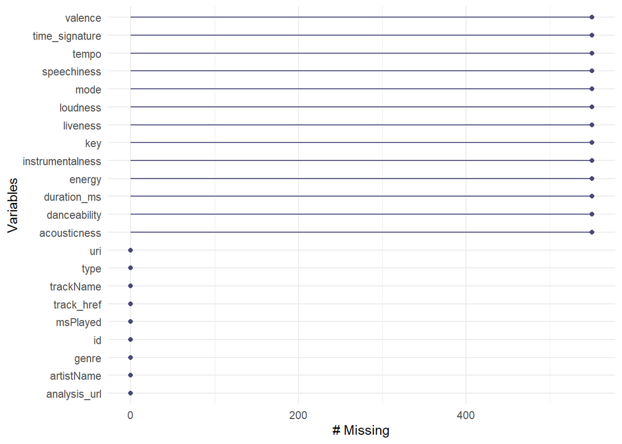

```r
library(naniar)
gg_miss_var(spotify_data)
```

#### Inference:

Our selected continuous variables—**danceability**, **energy**, and **tempo**—each have around 550 missing values, accounting for about 5.5% of the dataset. Since these variables are central to our regression analysis, removing rows with missing values would significantly reduce our sample size, potentially affecting the model’s reliability.

To address this, we considered different imputation methods: - **Mean or Median Imputation** could fill the gaps but might distort the distribution, especially if the data is skewed. - **K-Nearest Neighbors (KNN) Imputation** leverages similar observations to predict missing values, which helps maintain relationships within the data. - **Regression-Based Imputation** and **Multiple Imputation** are alternatives, but they can add complexity without necessarily improving the outcome for our purposes.

Given the balance between accuracy and practicality, **KNN imputation** is our chosen approach. It allows us to estimate missing values based on similarities in the dataset, preserving both data relationships and sample size for a more robust regression analysis.

Let’s proceed with KNN imputation to handle the missing values in our continuous variables.

**KNN Imputation for Missing Values**:

```r
# Specify the continuous variables with missing values
continuous_vars <- c("danceability", "energy", "tempo")

# Perform KNN imputation on the dataset for the specified columns
spotify_data_imputed <- kNN(spotify_data, variable = continuous_vars, k = 5)

# Check if missing values are handled
colSums(is.na(spotify_data_imputed))
```

```
##        trackName       artistName         msPlayed            genre
##                0                0                0                0
##     danceability           energy              key         loudness
##                0                0              550              550
##             mode      speechiness     acousticness instrumentalness
##              550              550              550              550
##         liveness          valence            tempo             type
##              550              550                0                0
##               id              uri       track_href     analysis_url
##                0                0                0                0
##      duration_ms   time_signature danceability_imp       energy_imp
##              550              550                0                0
##        tempo_imp
##                0
```

```r
# View the structure and summary after imputation
str(spotify_data_imputed)
```

```
## 'data.frame':    10080 obs. of  25 variables:
##  $ trackName       : chr  "\"Honest\"" "\"In The Hall Of The Mountain King\" from Peer Gynt Suite N°1, Op. 46" "#BrooklynBloodPop!" "$10" ...
##  $ artistName      : chr  "Nico Collins" "London Symphony Orchestra" "SyKo" "Good Morning" ...
##  $ msPlayed        : int  191772 1806234 145610 25058 5504949 2237969 441335 70589 120005 107407 ...
##  $ genre           : chr  "" "british orchestra" "glitchcore" "experimental pop" ...
##  $ danceability    : num  0.476 0.475 0.691 0.624 0.625 0.645 0.663 0.636 0.792 0.759 ...
##  $ energy          : num  0.799 0.13 0.814 0.596 0.726 0.611 0.904 0.335 0.511 0.699 ...
##  $ key             : num  4 7 1 4 11 8 7 NA 2 0 ...
##  $ loudness        : num  -4.94 -17.72 -3.79 -9.8 -11.4 ...
##  $ mode            : num  0 1 0 1 0 0 1 NA 1 0 ...
##  $ speechiness     : num  0.212 0.051 0.117 0.0314 0.0444 0.137 0.0857 NA 0.0409 0.0307 ...
##  $ acousticness    : num  0.0162 0.916 0.0164 0.475 0.0158 0.29 0.000708 NA 0.124 0.202 ...
##  $ instrumentalness: num  0.00 9.56e-01 0.00 2.03e-01 1.69e-04 2.05e-05 2.89e-01 NA 9.04e-05 1.31e-04 ...
##  $ liveness        : num  0.257 0.101 0.366 0.119 0.0625 0.237 0.341 NA 0.14 0.443 ...
##  $ valence         : num  0.577 0.122 0.509 0.896 0.507 0.645 0.675 NA 0.111 0.907 ...
##  $ tempo           : num  162 112 132 121 125 ...
##  $ type            : chr  "audio_features" "audio_features" "audio_features" "audio_features" ...
##  $ id              : chr  "7dTxqsaFGHOXwtzHINjfHv" "14Qcrx6Dfjvcj0H8oV8oUW" "7K9Z3yFNNLv5kwTjQYGjnu" "3koAwrM1RO0TGMeQJ3qt9J" ...
##  $ uri             : chr  "spotify:track:7dTxqsaFGHOXwtzHINjfHv" "spotify:track:14Qcrx6Dfjvcj0H8oV8oUW" "spotify:track:7K9Z3yFNNLv5kwTjQYGjnu" "spotify:track:3koAwrM1RO0TGMeQJ3qt9J" ...
##  $ track_href      : chr  "https://api.spotify.com/v1/tracks/7dTxqsaFGHOXwtzHINjfHv" "https://api.spotify.com/v1/tracks/14Qcrx6Dfjvcj0H8oV8oUW" "https://api.spotify.com/v1/tracks/7K9Z3yFNNLv5kwTjQYGjnu" "https://api.spotify.com/v1/tracks/3koAwrM1RO0TGMeQJ3qt9J" ...
##  $ analysis_url    : chr  "https://api.spotify.com/v1/audio-analysis/7dTxqsaFGHOXwtzHINjfHv" "https://api.spotify.com/v1/audio-analysis/14Qcrx6Dfjvcj0H8oV8oUW" "https://api.spotify.com/v1/audio-analysis/7K9Z3yFNNLv5kwTjQYGjnu" "https://api.spotify.com/v1/audio-analysis/3koAwrM1RO0TGMeQJ3qt9J" ...
##  $ duration_ms     : num  191948 150827 145611 89509 280400 ...
##  $ time_signature  : num  4 4 4 4 4 3 4 NA 4 4 ...
##  $ danceability_imp: logi  FALSE FALSE FALSE FALSE FALSE FALSE ...
##  $ energy_imp      : logi  FALSE FALSE FALSE FALSE FALSE FALSE ...
##  $ tempo_imp       : logi  FALSE FALSE FALSE FALSE FALSE FALSE ...
```

```r
summary(spotify_data_imputed[continuous_vars])
```

```
##   danceability        energy            tempo
##  Min.   :0.0000   Min.   :0.00108   Min.   :  0.00
##  1st Qu.:0.5170   1st Qu.:0.35200   1st Qu.: 99.02
##  Median :0.6330   Median :0.56800   Median :120.02
##  Mean   :0.6043   Mean   :0.55105   Mean   :119.95
##  3rd Qu.:0.7080   3rd Qu.:0.74000   3rd Qu.:137.77
##  Max.   :0.9760   Max.   :0.99900   Max.   :236.20
```

With the continuous variables (`danceability`, `energy`, `tempo`) and their missing values successfully handled using KNN imputation, we have ensured the dataset’s integrity while maintaining its structure. Additionally, the inclusion of indicator columns (`danceability_imp`, `energy_imp`, `tempo_imp`) allows us to trace imputed values and assess their impact on the analysis. To streamline our upcoming regression analysis, we will now create a reduced dataset containing only the essential columns: the response variable (`msPlayed`), selected predictors (`danceability`, `energy`, `tempo`, `genre`, and `artistName`), imputation indicators, and the `trackName` for identification. This focused dataset will simplify further processing while retaining all critical information.

#### Code to Create Reduced Dataset

```r
# Extract the required columns for analysis, including imputation indicators
columns_needed <- c("trackName", "msPlayed", "danceability", "danceability_imp", "energy", "energy_imp", "tempo", "tempo_imp", "genre", "artistName")
spotify_analysis_data <- spotify_data_imputed %>% select(all_of(columns_needed))

# View the structure of the new dataset to confirm
str(spotify_analysis_data)
```

```
## 'data.frame':    10080 obs. of  10 variables:
##  $ trackName       : chr  "\"Honest\"" "\"In The Hall Of The Mountain King\" from Peer Gynt Suite N°1, Op. 46" "#BrooklynBloodPop!" "$10" ...
##  $ msPlayed        : int  191772 1806234 145610 25058 5504949 2237969 441335 70589 120005 107407 ...
##  $ danceability    : num  0.476 0.475 0.691 0.624 0.625 0.645 0.663 0.636 0.792 0.759 ...
##  $ danceability_imp: logi  FALSE FALSE FALSE FALSE FALSE FALSE ...
##  $ energy          : num  0.799 0.13 0.814 0.596 0.726 0.611 0.904 0.335 0.511 0.699 ...
##  $ energy_imp      : logi  FALSE FALSE FALSE FALSE FALSE FALSE ...
##  $ tempo           : num  162 112 132 121 125 ...
##  $ tempo_imp       : logi  FALSE FALSE FALSE FALSE FALSE FALSE ...
##  $ genre           : chr  "" "british orchestra" "glitchcore" "experimental pop" ...
##  $ artistName      : chr  "Nico Collins" "London Symphony Orchestra" "SyKo" "Good Morning" ...
```

```r
# Display the first few rows of the new dataset
head(spotify_analysis_data)
```

```
##                                                             trackName msPlayed
## 1                                                            "Honest"   191772
## 2 "In The Hall Of The Mountain King" from Peer Gynt Suite N°1, Op. 46  1806234
## 3                                                  #BrooklynBloodPop!   145610
## 4                                                                 $10    25058
## 5                                          (I Just) Died In Your Arms  5504949
## 6                                                       (L)only Child  2237969
##   danceability danceability_imp energy energy_imp   tempo tempo_imp
## 1        0.476            FALSE  0.799      FALSE 162.139     FALSE
## 2        0.475            FALSE  0.130      FALSE 112.241     FALSE
## 3        0.691            FALSE  0.814      FALSE 132.012     FALSE
## 4        0.624            FALSE  0.596      FALSE 120.969     FALSE
## 5        0.625            FALSE  0.726      FALSE 124.945     FALSE
## 6        0.645            FALSE  0.611      FALSE 157.475     FALSE
##               genre                artistName
## 1                                Nico Collins
## 2 british orchestra London Symphony Orchestra
## 3        glitchcore                      SyKo
## 4  experimental pop              Good Morning
## 5        album rock              Cutting Crew
## 6             alt z               salem ilese
```

### Key Observations:

1. **Track Identifiers**:
   - `trackName`: This column contains the names of the tracks, which can serve as identifiers.
2. **Response Variable**:
   - `msPlayed`: Represents the playback duration in milliseconds.
3. **Continuous Predictors**:
   - `danceability`, `energy`, `tempo`: Key features relevant to predicting playback time.
   - Associated imputation flags (`danceability_imp`, `energy_imp`, `tempo_imp`) indicate whether these values were imputed during the data preparation process.
4. **Categorical Predictors**:
   - `genre` and `artistName`: These columns remain to be cleaned and standardized for use in the analysis.

#### Next Steps:

With the core columns identified, the focus now shifts to cleaning and standardizing the categorical columns (`genre` and `artistName`) and handling potential inconsistencies in `trackName`. Proper cleaning ensures consistency and reliability in the regression model.